# R Notebook

Non-random allocation of tiles

```r
library(ggplot2)
library(dplyr)
library(lwgeom)
library(MexBrewer)
library(sf)
library(truchet)
```

Create data frame for the mosaic:

```r
xlim <- c(0, 10)
ylim <- c(0, 10)

# Create a data frame with the spots for tiles
container <- expand.grid(x = seq(xlim[1], xlim[2], 1),
                         y = seq(ylim[1], ylim[2], 1)) %>%
  mutate(tiles = case_when(x <= 2 | x >= 8 ~ "dl",
                           x > 2 & x <8 ~ "dr"))
```

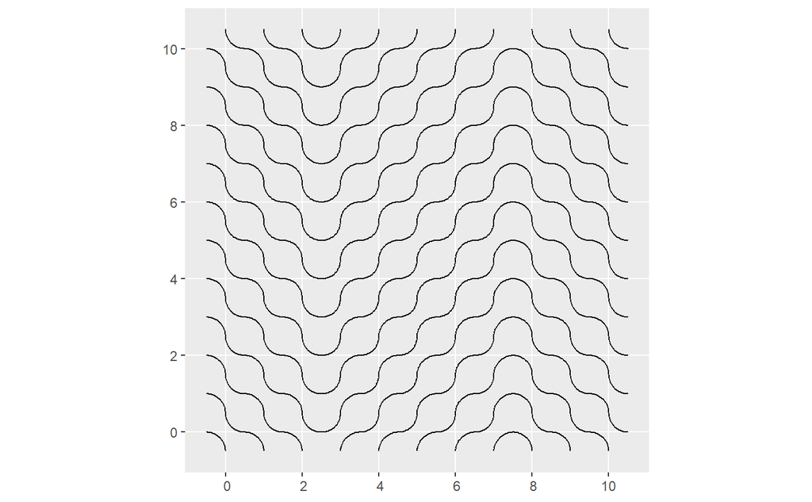

```r
st_truchet_ss(df = container) %>%
  ggplot() +
  geom_sf()
```

Create data frame for the mosaic:

```r
xlim <- c(0, 10)
ylim <- c(0, 10)

# Create a data frame with the spots for tiles
container <- expand.grid(x = seq(xlim[1], xlim[2], 1),
                         y = seq(ylim[1], ylim[2], 1)) %>%
  mutate(tiles = sample(c("dl", "dr"), n(), replace = TRUE))
```

Create mosaic using the designed container:

```r
mosaic <- st_truchet_ss(df = container)
```

Plot mosaic:

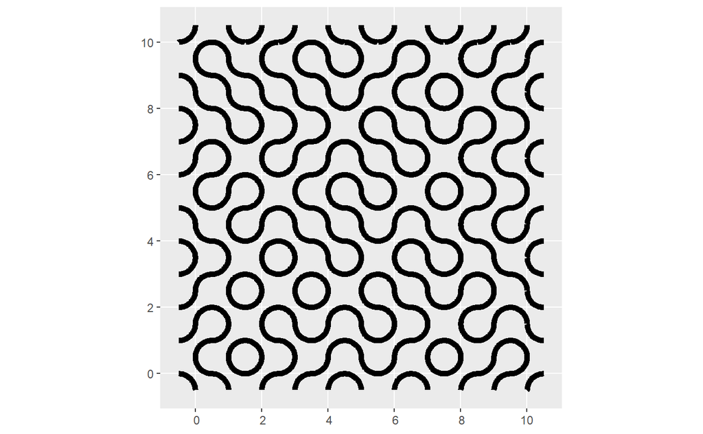

Plot with some embellishments:

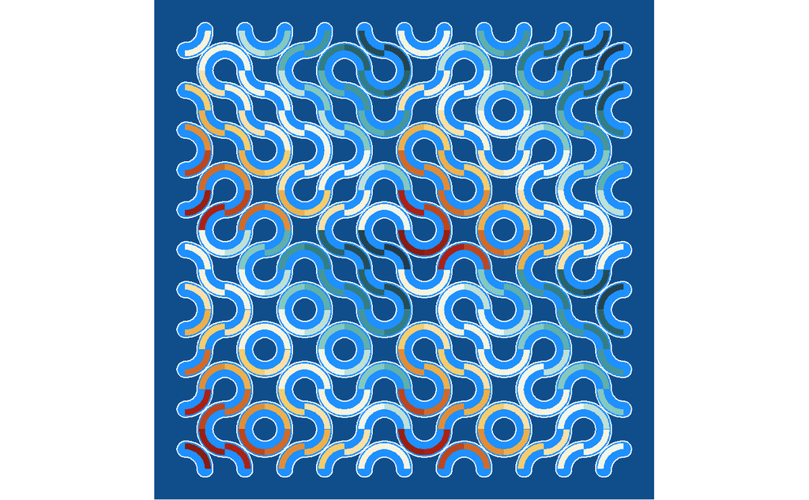

Plot with some embellishments:

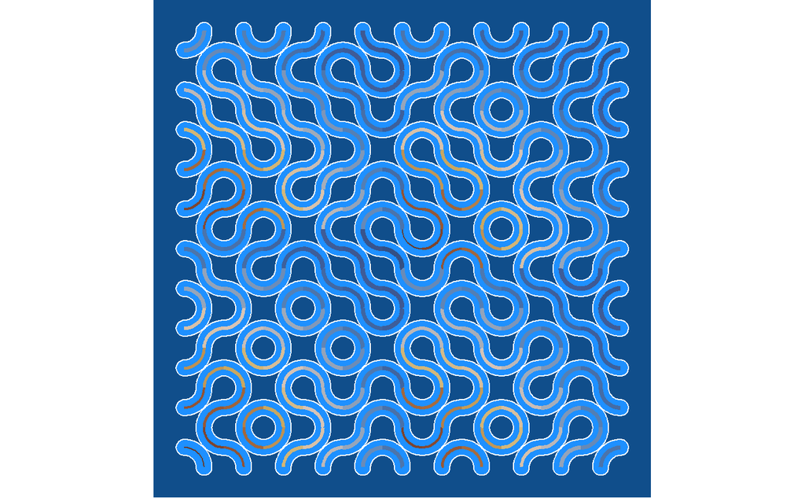

Create a polygon to contain the mosaic:

```r
 container <- matrix(c(0, 0,
                   0, 10,
                   10, 10,
                   10, 0,
                   0, 0),
                 ncol = 2,
                 byrow = TRUE)

  # Convert coordinates to polygons and then to simple features
  tile <- data.frame(geometry = sf::st_polygon(list(tile)) %>%
                       sf::st_sfc()) %>%
    sf::st_as_sf()
```

```
Error in stopifnot(is.list(x)) : object 'tile' not found
```

Split container

```r
container <- container%>%
  st_split(mosaic %>% st_union())
```

Extract geometries:

```r
container <- container %>%
  st_collection_extract(c("POLYGON"))
```

Plot container:

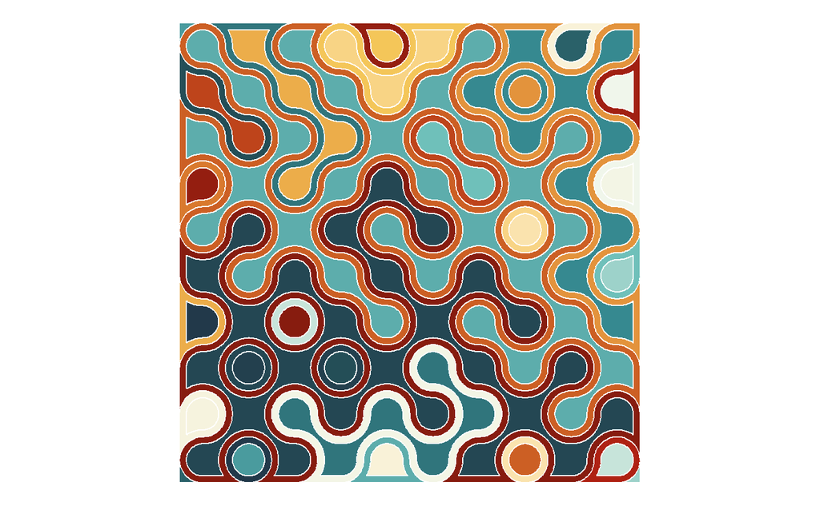

```r
ggsave("single-scale-polygons-revolucion-positive-buffers-2.png")
```

```r
ggsave("single-scale-polygons-revolucion-positive-buffers-3.png")
```

## Using images

```r
library(imager)
```

Read the image using `imager::load.image()`:

```r
elvis <- load.image("marilyin.jpg")
```

[output not shown]

Image info:

```r
marilyn
```

```
Image. Width: 800 pix Height: 1200 pix Depth: 1 Colour channels: 1
```

[figure not shown]

Resize image:

```r
marilyn_rs <- imresize(marilyn, scale = 1/8, interpolation = 6)
```

Convert to data frame:

```r
marilyn_df <- marilyn_rs %>%
  #grayscale() %>%
  as.data.frame() %>%
  mutate(y = -(y - max(y)))
```

[figure not shown]

```r
ggplot() +
  geom_point(data = marilyn_df,
             aes(x, y, color = value)) +
  coord_equal()
```

Create data frame for the mosaic:

```r
xlim <- c(min(marilyn_df$x)/8 - 2, max(marilyn_df$x)/8 + 2)
ylim <- c(min(marilyn_df$y)/8 - 2, max(marilyn_df$y)/8 + 2)

# Create a data frame with the spots for tiles
mosaic <- expand.grid(x = seq(xlim[1], xlim[2], 1),
                         y = seq(ylim[1], ylim[2], 1)) %>%
  mutate(tiles = sample(c("dl", "dr"), n(), replace = TRUE))
```

Create mosaic using the designed container:

```r
mosaic <- st_truchet_ss(df = mosaic)
```

Plot mosaic:

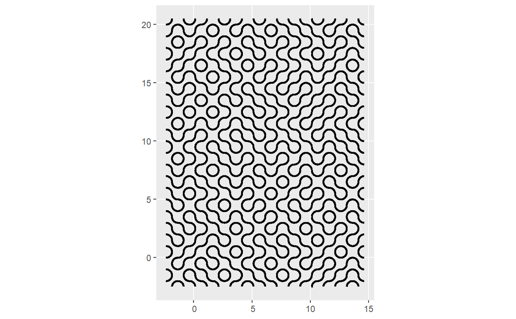

```r
ggplot() +
  geom_sf(data = mosaic,
          size = 1)
```

Now this needs to be scaled to the size of the image. First get the union of the geometries:

```r
mosaic_union <- st_union(mosaic)
```

```r
mosaic_union <- mosaic_union * 8
```

Create a polygon to contain the mosaic:

```r
 container <- matrix(c(min(marilyn_df$x), min(marilyn_df$y),
                   min(marilyn_df$x), max(marilyn_df$y),
                   max(marilyn_df$x), max(marilyn_df$y),
                   max(marilyn_df$x), min(marilyn_df$y),
                   min(marilyn_df$x), min(marilyn_df$y)),
                 ncol = 2,
                 byrow = TRUE)

  # Convert coordinates to polygons and then to simple features
  container <- data.frame(geometry = sf::st_polygon(list(container)) %>%
                       sf::st_sfc()) %>%
    sf::st_as_sf()
```

Split container

```r
mosaic <- container %>%
  st_split(mosaic_union)
```

Extract geometries:

```r
mosaic <- mosaic %>%
  st_collection_extract(c("POLYGON"))
```

Create buffers:

```r
mosaic_1 <- mosaic %>%
  st_buffer(dist = -1)

mosaic_2 <- mosaic %>%
  st_buffer(dist = -2)

mosaic_3 <- mosaic %>%
  st_buffer(dist = -3)
```

```r
ggsave("marilyn-truchet.png")
```